# DESI_BGS_color_redshift_relation_exercise

```python
import astropy.io.fits as pf
import matplotlib.pyplot as plt
import numpy as np
import scipy.integrate
from astropy.cosmology import FlatLambdaCDM
import astropy.units as u
cosmo = FlatLambdaCDM(H0=70 * u.km / u.s / u.Mpc, Tcmb0=2.725 * u.K, Om0=0.3)
```

```python
import seaborn as sns

sns.set_theme(
    style="ticks",
    context="notebook",
    rc={
        "axes.linewidth": 1.2,
        "axes.labelsize": 13,
        "axes.titlesize": 14,
        "xtick.labelsize": 11,
        "ytick.labelsize": 11,
        "legend.fontsize": 11,
        "figure.dpi": 120
    }
)
```

```python
### data
### https://www.dropbox.com/scl/fi/5pmz5z2h13381duajnrzr/BGS_ANY_full_noveto_good_z_cut_CIGALE_small.fits?rlkey=syw7r2sk82yk4vgh23ozonc2d&e=1&dl=0
```

### Reloading DESI BGS galaxy catalog with CIGALE SED fitting information

```python
data = pf.open('../data/BGS_ANY_full_noveto_good_z_cut_CIGALE_small_SERSIC.fits')
```

### Print out the information in the catalog

```python
print(data[1].data.names)
```

```
['TARGETID_1', 'MWS_TARGET', 'SUBPRIORITY', 'PRIORITY_INIT', 'TARGET_STATE', 'TIMESTAMP', 'LOCATION', 'TILEID', 'TILELOCID', 'LASTNIGHT', 'Z_1', 'ZERR', 'ZWARN', 'CHI2_1', 'COEFF', 'NPIXELS', 'SPECTYPE_1', 'SUBTYPE', 'NCOEFF', 'DELTACHI2', 'FIBER', 'COADD_FIBERSTATUS', 'FIBERASSIGN_X', 'FIBERASSIGN_…
```

### Observed magntidues with reddening correction

```python
mag_g = 22.5-2.5*np.log10(data[1].data['FLUX_G_1']/data[1].data['MW_TRANSMISSION_G_1'])
mag_r = 22.5-2.5*np.log10(data[1].data['FLUX_R_1']/data[1].data['MW_TRANSMISSION_R_1'])
mag_z = 22.5-2.5*np.log10(data[1].data['FLUX_Z_1']/data[1].data['MW_TRANSMISSION_Z_1'])
```

### Absolute magnitudes

```python
print(np.min(data[1].data['LNU_G']))
print(np.sum(data[1].data['LNU_G'] <= 0))
```

```
-1.5755654497162806e+22
65
```

Some values of LNU_G, LNU_R, and LNU Z are non-positive. Since the logarithm is only defined for positive values, we exclude these entries before computing magnitudes.

```python
good = (
    (data[1].data['LNU_G'] > 0) &
    (data[1].data['LNU_R'] > 0) &
    (data[1].data['LNU_Z'] > 0)
)

abs_g = np.full(len(data[1].data['LNU_G']), np.nan)
abs_r = np.full(len(data[1].data['LNU_R']), np.nan)
abs_z = np.full(len(data[1].data['LNU_Z']), np.nan)

abs_g[good] = -2.5 * np.log10(data[1].data['LNU_G'][good]) + 34.1
abs_r[good] = -2.5 * np.log10(data[1].data['LNU_R'][good]) + 34.1
abs_z[good] = -2.5 * np.log10(data[1].data['LNU_Z'][good]) + 34.1

# abs_g = -2.5*np.log10(data[1].data['LNU_G'])+34.1
# abs_r = -2.5*np.log10(data[1].data['LNU_R'])+34.1
# abs_z = -2.5*np.log10(data[1].data['LNU_Z'])+34.1
```

### observed color-redshift relation

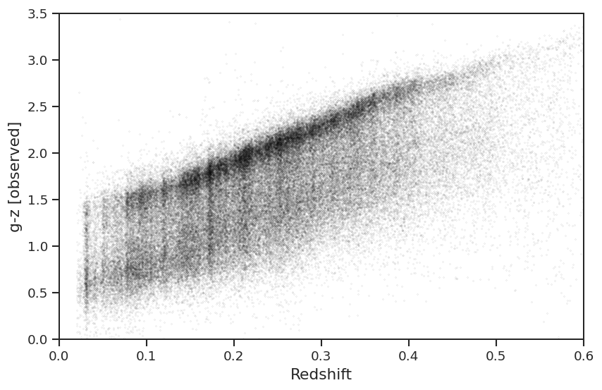

```python
plt.figure(figsize=(8,5))
plt.scatter(data[1].data['Z_1'],(mag_g-mag_z),s=0.002,color='black')

plt.xlim(0,0.6)
plt.ylim(0,3.5)
plt.ylabel('g-z [observed]')
plt.xlabel('Redshift')
```

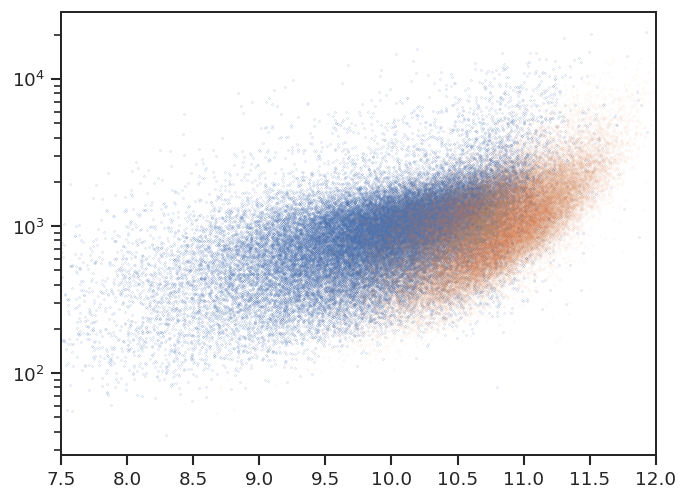

```python
cut = ((abs_g-abs_z)<1.1) #& (data[1].data['Z_1']<0.1)
plt.scatter(data[1].data['LOGM'][cut],data[1].data['SHAPE_R'][cut]*cosmo.angular_diameter_distance(data[1].data['Z_1'][cut]),s=0.01)

cut = ((abs_g-abs_z)>1.1) #& (data[1].data['Z_1']<0.1)
plt.scatter(data[1].data['LOGM'][cut],data[1].data['SHAPE_R'][cut]*cosmo.angular_diameter_distance(data[1].data['Z_1'][cut]),s=0.001)

plt.xlim(7.5,12)
#plt.ylim(0,10)
plt.yscale('log')
```

### Absolute color-redshift relation

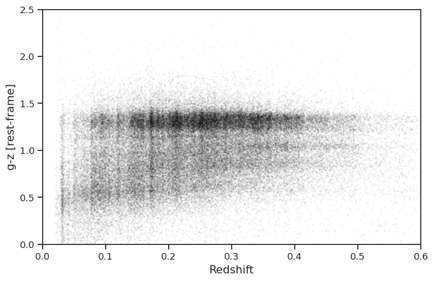

```python
plt.figure(figsize=(8,5))
plt.scatter(data[1].data['Z_1'],(abs_g-abs_z),s=0.002,color='black')
plt.xlim(0,0.6)
plt.ylim(0,2.5)
plt.ylabel('g-z [rest-frame]')
plt.xlabel('Redshift')
```

# HW1

## 1. We discuss that there are correlations between galaxy stellar mass, colors, morphology and sizes. In the following, we are going to use DESI data to explore some of the relationships.

### 1.1 Select blue galaxies with g-z<1.1 (rest-frame) and plot the their distribution of SERSIC index [column "SERSIC"]

### 1.2 Select red galaxies with g-z>1.1 (rest-frame) and plot the distribution of SERSIC index [column "SERSIC"]

### 1.3 What do you observe? Are the distributions consistent with what we discussed in the class?

### 1.4 If you find some sources which do not have the consistent properties (e.g. blue but high Sersic index). Select the first 100 sources and print their RA_1 and DEC_1 and look at their images at https://yymao.github.io/decals-image-list-tool/ . Based on your observations, what are the possible reasons for the inconsistency?

### 1.5 We now explore the size distribution of galaxies. column SHAPE_R (arcsec) provides the observed sizes of galaxies. Convert them into physical sizes in unit of kpc (check the angular diameter distance and the unit in astropy document).

### Plot x-axis (stellar mass LOGM) and y-axis galaxy sizes for blue galaxies (g-z<1.1) and red galaxies (g-z>1.1). (ignore the data with LOGM<7.5). What do you observe? Are the results consistent with what we discussed?

### 1.6 Plot x-axis redshifts (Z_1) and y-axis stellar mass (LOGM) [Again ignore the data with LOGM<7.5]. There is a trend between stellar mass and redshifts. What causes such a trend?

### 1.7 Plot stellar mass (x-axis) to color g-z relation (y-axis). You will find that there are fewer red galaxies at lower mass end. What is the reason for this behavior?

### 1.8 We now explore the mass-to-light ratio. Plot M/L ratio (y-axis) and g-r (absolute color, x-axis). [To do so, you need to convert LNU_G [W/Hz] into the unit of solar luminosity in G band.] Is your result consistent with Fig 6 of Bell et al. (2003) [[https://arxiv.org/pdf/astro-ph/0302543]?](https://arxiv.org/pdf/astro-ph/0302543%5D?) Do you observe any differences?

### 1.9 Color the M/L vs g-r scatter plot with stellar mass. Is there a mass-dependent trend for the M/L ratio?

### 1.10 Based on the information provided by the catalog, calculate and plot the K-correction for g, r, z bands (y-axis) as a function of redshift (x-axis) [3 figures] and color code the data points with the g-z color. Do you observe any color dependence on the K-correction? Are your results consistent with Fukugita et al. (1995)? )

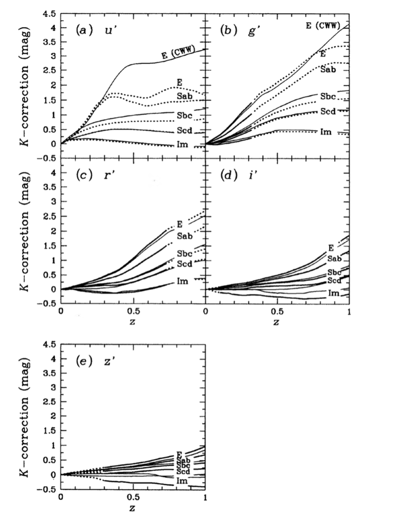

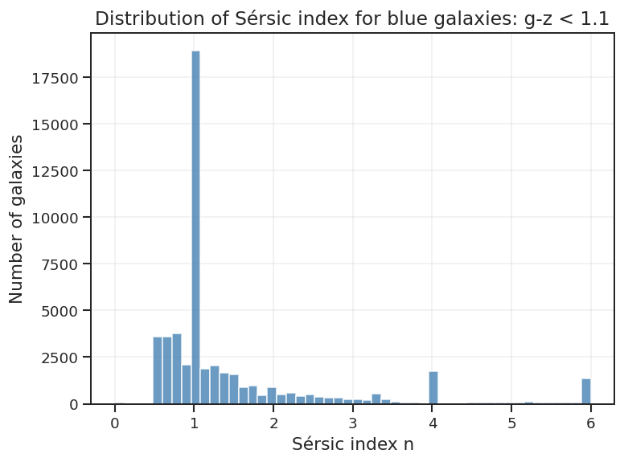

```
Number of blue galaxies: 51310
Median Sérsic index: 1.0
```

```python
# 1.1 Blue galaxies: rest-frame g-z < 1.1

rest_gz = abs_g - abs_z

blue = (
    np.isfinite(rest_gz) &
    np.isfinite(data[1].data['SERSIC']) &
    (rest_gz < 1.1)
)

sersic_blue = data[1].data['SERSIC'][blue]

plt.figure(figsize=(7, 5))
plt.hist(sersic_blue, bins=50, color='steelblue', alpha=0.8)
plt.xlabel('Sérsic index n')
plt.ylabel('Number of galaxies')
plt.title('Distribution of Sérsic index for blue galaxies: g-z < 1.1')
plt.grid(alpha=0.3)
plt.show()

print("Number of blue galaxies:", np.sum(blue))
print("Median Sérsic index:", np.nanmedian(sersic_blue))
```

The distribution peaks around n ≈ 1, which is common for exponential light profiles. This suggests that many blue galaxies are probably disk-like systems.

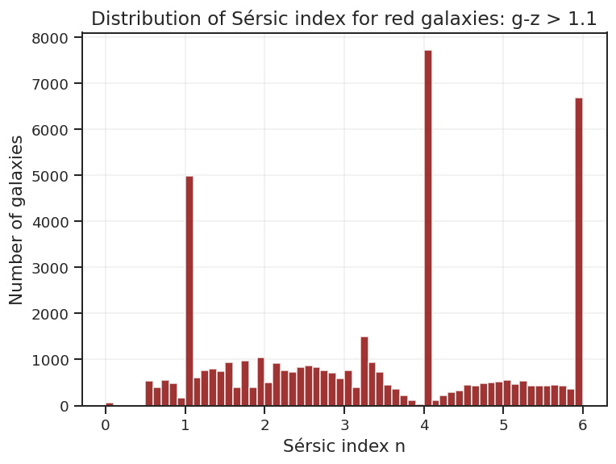

```
Number of red galaxies: 48621
Median Sérsic index: 3.3226554
```

```python
# 1.2 Red galaxies: rest-frame g-z > 1.1

red = (
    np.isfinite(rest_gz) &
    np.isfinite(data[1].data['SERSIC']) &
    (rest_gz > 1.1)
)

sersic_red = data[1].data['SERSIC'][red]

plt.figure(figsize=(7, 5))
plt.hist(sersic_red, bins=np.linspace(0, 6, 61), color='darkred', alpha=0.8)
plt.xlabel('Sérsic index n')
plt.ylabel('Number of galaxies')
plt.title('Distribution of Sérsic index for red galaxies: g-z > 1.1')
plt.grid(alpha=0.3)
plt.show()

print("Number of red galaxies:", np.sum(red))
print("Median Sérsic index:", np.nanmedian(sersic_red))
```

These observations are consistent with our class discussions. The lecture demonstrated that galaxy colour exhibits a bimodal distribution and is correlated with the Sérsic index. Specifically, blue galaxies tend to be more disk-like with lower n values, whereas red galaxies are typically bulge-dominated or elliptical-like with higher n values.

However, this separation is not absolute. Some red galaxies exhibit low Sérsic indices, and some blue galaxies display high Sérsic indices. Therefore, while colour and morphology are correlated, they do not represent identical classification schemes.

```python
# 1.4 Blue galaxies with high Sérsic index

sersic = data[1].data['SERSIC']
ra = data[1].data['RA_1']
dec = data[1].data['DEC_1']

# inconsistent case: blue colour but high Sérsic index
blue_high_sersic = (
    np.isfinite(rest_gz) &
    np.isfinite(sersic) &
    np.isfinite(ra) &
    np.isfinite(dec) &
    (rest_gz < 1.1) &
    (sersic > 3)
)

idx = np.where(blue_high_sersic)[0]

print("Number of blue galaxies with high Sérsic index:", len(idx))

# first 100 sources
idx100 = idx[:100]

print("NAME RA DEC")
for j, i in enumerate(idx100):
    print(f"source_{j+1:03d} {ra[i]:.6f} {dec[i]:.6f}")
```

```
Number of blue galaxies with high Sérsic index: 5538
NAME RA DEC
source_001 22.092516 -19.407431
source_002 22.331182 -19.425681
source_003 48.307269 -19.413273
source_004 10.807797 -19.159255
source_005 10.995120 -19.234234
source_006 11.027909 -19.321777
source_007 11.321942 -19.170553
source_008 11.521044 -19.230253
source_009 11.596107 -19.309995
source_010 21.189528 -19.133416
source_011 21.266848 -19.260138
source_012 21.773100 -19.352835
source_013 21.821659 -19.230920
source_014 21.914247 -19.361472
source_015 21.937486 -19.249599
source_016 22.011665 -19.263567
source_017 22.099131 -19.161736
source_018 22.246623 -19.291578
source_019 22.304661 -19.217651
source_020 22.751237 -19.243466
source_021 22.940188 -19.153887
source_022 47.890467 -19.288280
source_023 48.348332 -19.284515
source_024 48.373071 -19.226174
source_025 48.429776 -19.289127
source_026 48.514944 -19.176666
source_027 48.684553 -19.262675
source_028 48.740204 -19.159176
source_029 48.749669 -19.289005
source_030 48.796371 -19.250813
source_031 48.854440 -19.323287
source_032 48.872089 -19.224277
source_033 49.042274 -19.157664
source_034 49.098713 -19.132978
source_035 61.761697 -19.213782
source_036 61.880398 -19.172335
source_037 62.310085 -19.229168
source_038 62.346084 -19.329731
```

[output cut: 47 more lines]

```
source_086 62.158132 -19.093726
source_087 62.304999 -19.105492
source_088 62.610058 -18.977148
source_089 62.657952 -19.068793
source_090 62.802944 -19.106378
source_091 10.295105 -18.643061
source_092 10.548611 -18.779488
source_093 10.844821 -18.788355
source_094 10.853054 -18.863878
source_095 10.932904 -18.661652
source_096 11.114656 -18.775952
source_097 11.227972 -18.784558
source_098 11.280672 -18.743675
source_099 11.770313 -18.679988
source_100 11.858041 -18.726553
```

The images show that many of these objects are not simple disk galaxies, the global colour may be blue due to young star-forming regions, yet the light profile remains centrally concentrated, resulting in a high Sérsic index. Other possible reasons include contamination from nearby stars or galaxies, mergers/interactions and limitations of fitting a complex galaxy with a single Sérsic profile.

Therefore, the inconsistency is expected: while colour and Sérsic index are correlated, they do not always represent the same physical property.

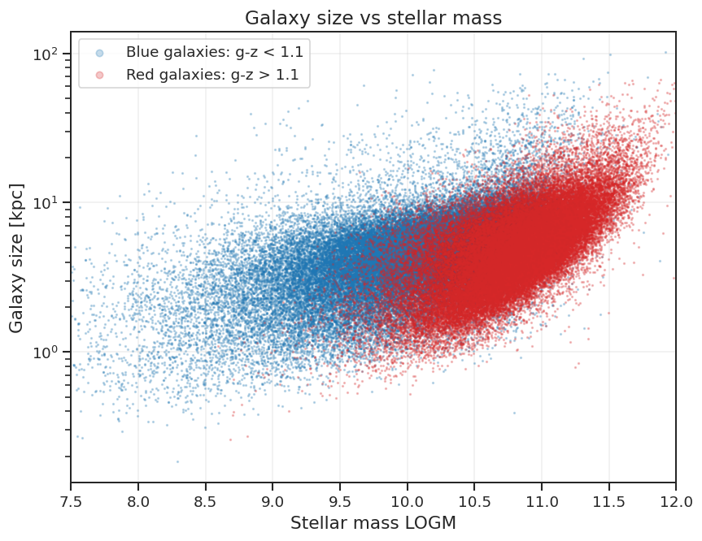

```python
# 1.5 Size-mass relation for blue and red galaxies

z = data[1].data['Z_1']
logm = data[1].data['LOGM']
shape_r = data[1].data['SHAPE_R']   # arcsec
rest_gz = abs_g - abs_z

# physical size = angular size in radians * angular diameter distance
DA_kpc = cosmo.angular_diameter_distance(z).to(u.kpc).value
theta_rad = (shape_r * u.arcsec).to(u.rad).value
size_kpc = theta_rad * DA_kpc

# Basic good data cut
good_size = (
    np.isfinite(rest_gz) &
    np.isfinite(logm) &
    np.isfinite(size_kpc) &
    np.isfinite(z) &
    (logm >= 7.5) &
    (size_kpc > 0)
)

blue = good_size & (rest_gz < 1.1)
red = good_size & (rest_gz > 1.1)

plt.figure(figsize=(8, 6))

plt.scatter(logm[blue], size_kpc[blue],
            s=1, alpha=0.25, color='tab:blue',
            label='Blue galaxies: g-z < 1.1')

plt.scatter(logm[red], size_kpc[red],
            s=1, alpha=0.25, color='tab:red',
            label='Red galaxies: g-z > 1.1')

plt.xlabel('Stellar mass LOGM')
plt.ylabel('Galaxy size [kpc]')
plt.title('Galaxy size vs stellar mass')
plt.yscale('log')
plt.xlim(7.5, 12)
plt.grid(alpha=0.3)
plt.legend(markerscale=5)
plt.show()
```

Galaxy size generally increases with stellar mass. At a given stellar mass, blue galaxies are typically larger than red galaxies, which are more compact.

This aligns with our class discussion that galaxy colour, morphology, stellar mass, and size are correlated.

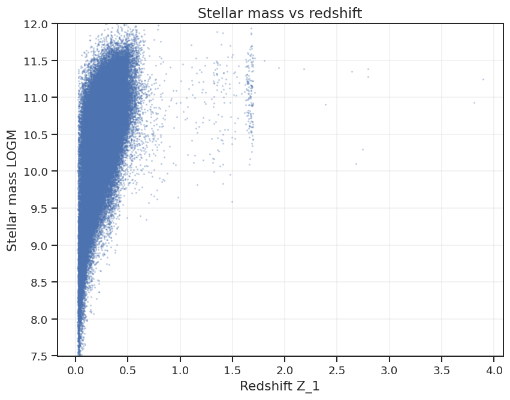

```python
# 1.6 Redshift vs stellar mass

z = data[1].data['Z_1']
logm = data[1].data['LOGM']

good = (
    np.isfinite(z) &
    np.isfinite(logm) &
    (logm >= 7.5) &
    (z > 0)
)

plt.figure(figsize=(8, 6))
plt.scatter(z[good], logm[good], s=1, alpha=0.25)
plt.xlabel('Redshift Z_1')
plt.ylabel('Stellar mass LOGM')
plt.title('Stellar mass vs redshift')
plt.ylim(7.5, 12)
plt.grid(alpha=0.3)
plt.show()
```

The plot shows that low-mass galaxies are mostly at low redshift, while at higher redshift the sample mainly contains massive galaxies. This is due to the survey's flux limit. Low-mass galaxies are fainter and become undetectable at larger distances. Massive galaxies are brighter and observed over larger volumes. Thus, the correlation between stellar mass and redshift is mainly due to selection effects rather than a physical trend.

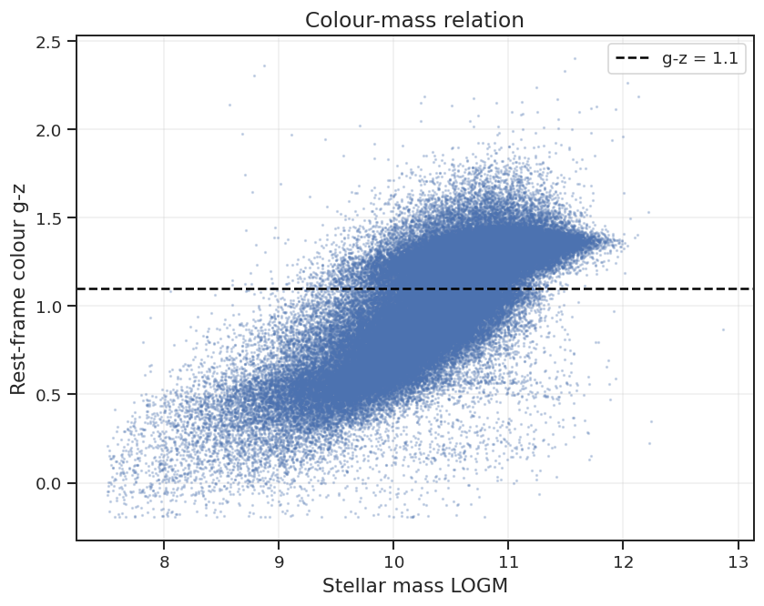

```python
# 1.7 Stellar mass vs colour g-z

logm = data[1].data['LOGM']
rest_gz = abs_g - abs_z

good = (
    np.isfinite(logm) &
    np.isfinite(rest_gz) &
    (logm >= 7.5)
)

plt.figure(figsize=(8, 6))
plt.scatter(logm[good], rest_gz[good], s=1, alpha=0.25)

plt.axhline(1.1, color='black', linestyle='--', label='g-z = 1.1')

plt.xlabel('Stellar mass LOGM')
plt.ylabel('Rest-frame colour g-z')
plt.title('Colour-mass relation')
plt.grid(alpha=0.3)
plt.legend()
plt.show()
```

The plot indicates that low-mass galaxies are predominantly blue, while red galaxies are more common at higher stellar masses. Low-mass galaxies typically continue forming stars, resulting in young, blue stellar populations. In contrast, massive galaxies are often quenched, with star formation ceased, leading to older, redder stellar populations.

A secondary reason may be selection bias: low-mass red galaxies are faint and harder to detect, so they may be under-represented in the sample.

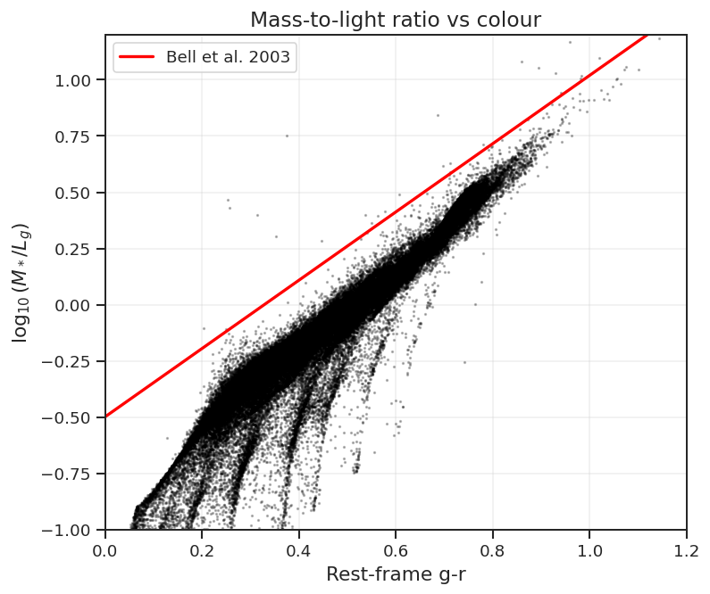

```python
# Solar absolute magnitude in SDSS g band, AB system
M_sun_g = 5.12

# M_AB = -2.5 log10(Lnu) + 34.1
Lnu_sun_g = 10**((34.1 - M_sun_g) / 2.5)

L_g_solar = lnu_g / Lnu_sun_g
Mstar = 10**logm
ml_g = Mstar / L_g_solar

good = (
    np.isfinite(gr) &
    np.isfinite(logm) &
    np.isfinite(lnu_g) &
    np.isfinite(ml_g) &
    (lnu_g > 0) &
    (ml_g > 0) &
    (logm >= 7.5)
)

log_ml_g = np.log10(ml_g[good])

plt.figure(figsize=(7, 6))
plt.scatter(gr[good], log_ml_g, s=1, alpha=0.25, color='black')

# Bell et al. 2003 relation for g band
x = np.linspace(0, 1.2, 100)
y_bell = -0.499 + 1.519 * x

plt.plot(x, y_bell, color='red', linewidth=2, label='Bell et al. 2003')

plt.xlabel('Rest-frame g-r')
plt.ylabel(r'$\log_{10}(M_*/L_g)$')
plt.title('Mass-to-light ratio vs colour')
plt.xlim(0, 1.2)
plt.ylim(-1, 1.2)
plt.grid(alpha=0.3)
plt.legend()
plt.show()
```

We observe the same positive correlation: redder galaxies have higher mass-to-light ratios. However, the agreement is not perfect. Our relation is systematically lower than the Bell et al. line and shows more scatter. This difference may result from stellar mass estimates, dust treatment, and sample selection.

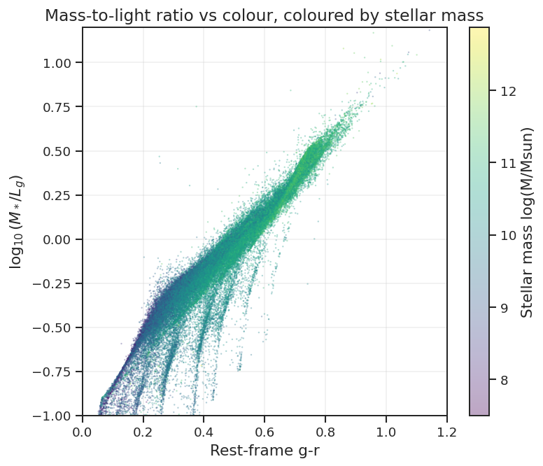

```python
# 1.9 M/L vs g-r, coloured by stellar mass

plt.figure(figsize=(7, 6))

sc = plt.scatter(
    gr[good],
    log_ml_g,
    c=logm[good],
    s=2,
    alpha=0.35,
    cmap='viridis',
    linewidths=0
)

plt.colorbar(sc, label='Stellar mass log(M/Msun)')
plt.xlabel('Rest-frame g-r')
plt.ylabel(r'$\log_{10}(M_*/L_g)$')
plt.title('Mass-to-light ratio vs colour, coloured by stellar mass')
plt.xlim(0, 1.2)
plt.ylim(-1, 1.2)
plt.grid(alpha=0.3)
plt.show()
```

Yes, there is a mass-dependent trend. At fixed g-r, more massive galaxies tend to have higher M/L. High-mass galaxies are concentrated at the red, high-M/L end, while low-mass galaxies are more common at the blue, low-M/L end. Massive galaxies usually have older stellar populations and less star formation, so they emit less light per unit stellar mass.

# 1.10 K-correction vs redshift for g, r, z bands

K = m_observed - M_restframe - distance_modulus

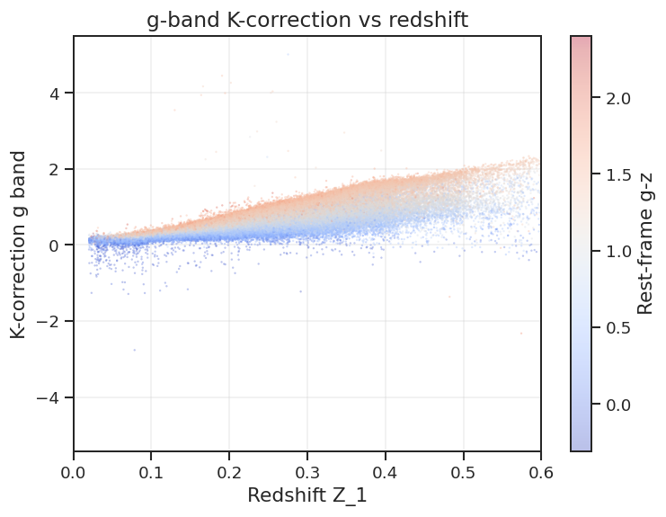

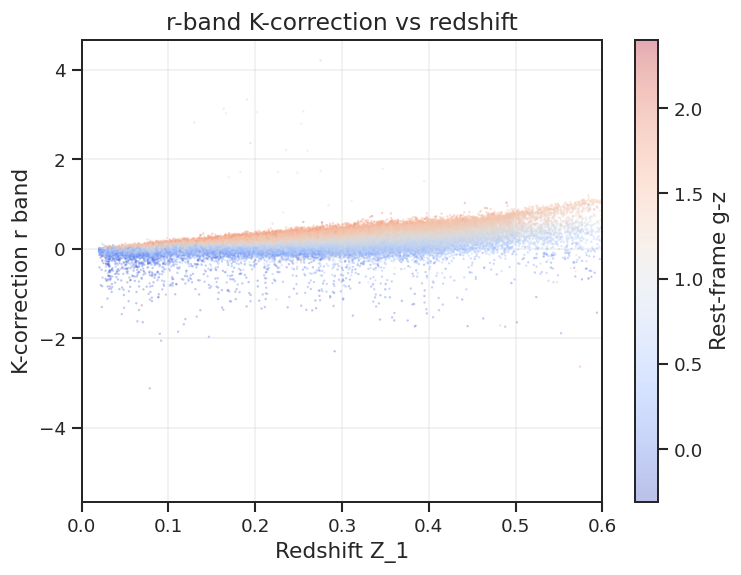

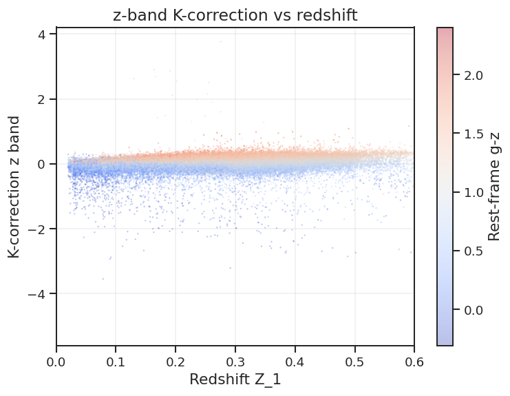

```python
z = data[1].data['Z_1']

# rest-frame colour for colour-coding
gz_color = abs_g - abs_z

# distance modulus
dm = cosmo.distmod(z).value

# K-corrections
k_g = mag_g - abs_g - dm
k_r = mag_r - abs_r - dm
k_z = mag_z - abs_z - dm

good = (
    np.isfinite(z) &
    np.isfinite(gz_color) &
    np.isfinite(k_g) &
    np.isfinite(k_r) &
    np.isfinite(k_z) &
    (z > 0)
)

def plot_kcorr(kcorr, band_name):
    plt.figure(figsize=(7, 5))

    sc = plt.scatter(
        z[good],
        kcorr[good],
        c=gz_color[good],
        s=2,
        alpha=0.35,
        cmap='coolwarm',
        linewidths=0
    )

    plt.colorbar(sc, label='Rest-frame g-z')
    plt.xlabel('Redshift Z_1')
    plt.ylabel(f'K-correction {band_name} band')
    plt.title(f'{band_name}-band K-correction vs redshift')
    plt.xlim(0, 0.6)
    plt.grid(alpha=0.3)
    plt.show()

plot_kcorr(k_g, 'g')
plot_kcorr(k_r, 'r')
plot_kcorr(k_z, 'z')
```

The K-correction clearly depends on galaxy colour. At fixed redshift, redder galaxies with larger rest-frame g-z generally have larger K-corrections than bluer ones. This colour dependence is strongest in the g band, weaker in the r band, and weakest in the z band. The K-correction also increases with redshift, especially in the bluer bands.

This is qualitatively consistent with Fukugita, Shimasaku & Ichikawa Fig. 20, where different galaxy SED types produce different K-correction curves in the SDSS filters.

The main difference is that our plots show a continuous scatter of real galaxies colour-coded by g-z instead of a few smooth template curves. The scatter is expected because real galaxies vary in SEDs and dust content. Overall, the trend is consistent: K-correction depends on both redshift and galaxy colour.